## Title: “Linear regression of corals and inverts”

author: “Journ Galvan” date: “4/23/2020” output: html_document —

### Correlating morphological measurements

##### For this step we related coral volume to surface area and avgerage branch width measurements. Summary data from the linear regression was extracted and exported to a table using the *tab_model( )* function and was then applied to all other linear models in the R markdown document.

##### We first assesed $p<0.05$ to test if the linear regression slope was significantly different from zero. Correlation of dependent and independent variables $R^2$ was also included in the tables. If the slopes were signficiant, we compared confidence intervals for overlap to give a conservative estimate if the slopes were signficantly different from eachother. Linear regressions for both tight and wide branching corals were overlayed on the same graph to show differences in their slope and standard error was included around the line for visual interpretation.

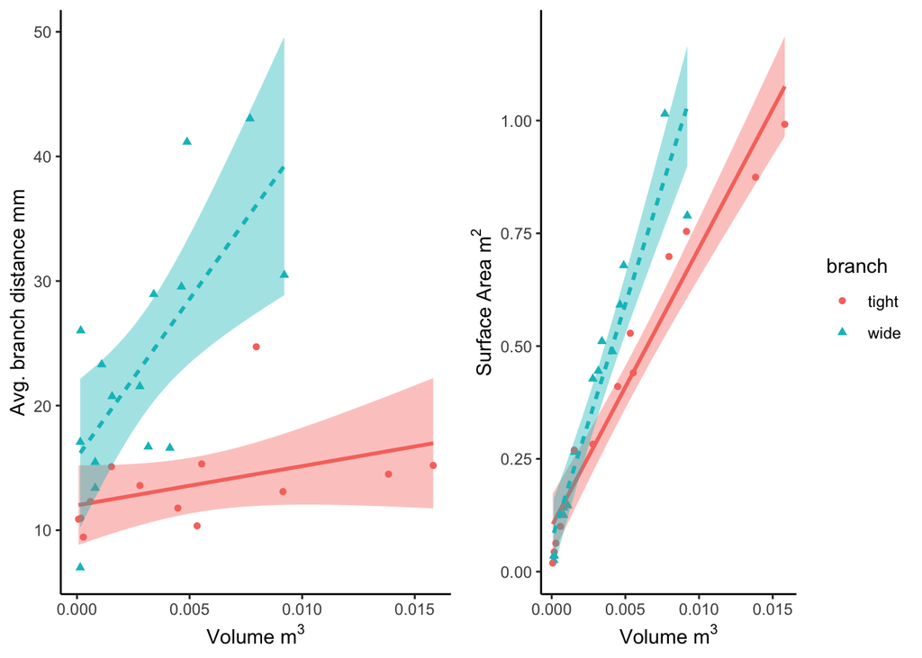

|  | Tight branching avg. distance |  |  | Wide branching avg. distance |  |  |
| --- | --- | --- | --- | --- | --- | --- |
| Predictors | Estimates | CI | p | Estimates | CI | p |
| Intercept | 12.00 | 8.78 – 15.21 | **<0.001** | 15.83 | 9.71 – 21.96 | **<0.001** |
| Volume | 314.86 | -130.07 – 759.80 | 0.148 | 2543.12 | 1013.11 – 4073.12 | **0.003** |
| Observations | 13 |  |  | 15 |  |  |
| R<sup>2</sup> / R<sup>2</sup> adjusted | 0.181 / 0.106 |  |  | 0.498 / 0.459 |  |  |

[output not shown]

### Visualize invertebrate data

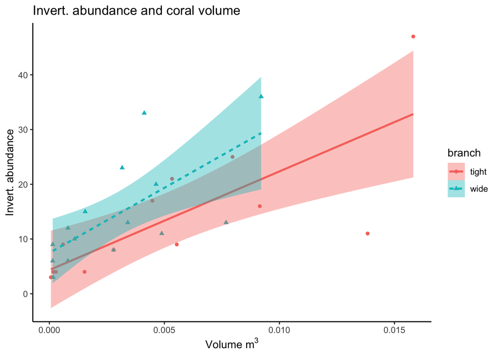

|  | Invert abundance in tight coral |  |  | Invert abundance in wide coral |  |  |
| --- | --- | --- | --- | --- | --- | --- |
| Predictors | Estimates | CI | p | Estimates | CI | p |
| Intercept | 4.33 | -2.80 – 11.46 | 0.208 | 7.46 | 1.39 – 13.53 | **0.020** |
| Volume | 1801.68 | 814.98 – 2788.39 | **0.002** | 2377.25 | 860.80 – 3893.70 | **0.005** |
| Observations | 13 |  |  | 15 |  |  |
| R<sup>2</sup> / R<sup>2</sup> adjusted | 0.595 / 0.558 |  |  | 0.469 / 0.428 |  |  |

##### The slopes are both significantly different from zero. Coral volume and invert abundance appear to be more correlated for tight branching coral. Confidence intervals for slopes are highly overlapping and we can not confidently conclude that the differences in slopes are signficant.

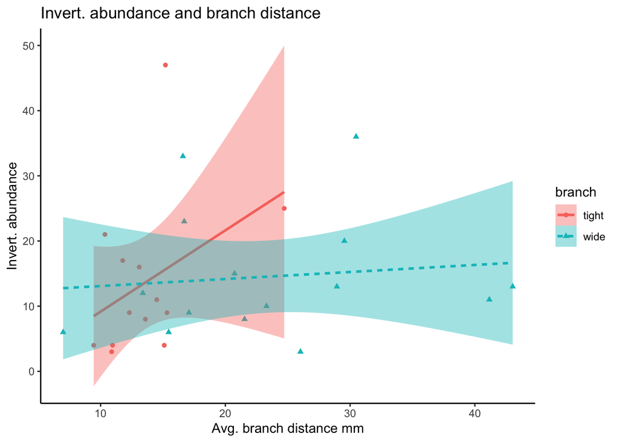

|  | Invert abundance in tight coral |  |  | Invert abundance in wide coral |  |  |
| --- | --- | --- | --- | --- | --- | --- |
| Predictors | Estimates | CI | p | Estimates | CI | p |
| Intercept | -3.31 | -30.48 – 23.85 | 0.793 | 12.01 | -2.51 – 26.53 | 0.097 |
| Avg. branch width | 1.25 | -0.67 – 3.17 | 0.181 | 0.11 | -0.47 – 0.68 | 0.691 |
| Observations | 13 |  |  | 15 |  |  |
| R<sup>2</sup> / R<sup>2</sup> adjusted | 0.156 / 0.080 |  |  | 0.013 / -0.063 |  |  |

##### None of the slopes are significantly different from zero when comparing avg. branch distance and invert abundance. We also cannot confidently conclude that the slopes are significantly different from eachother.

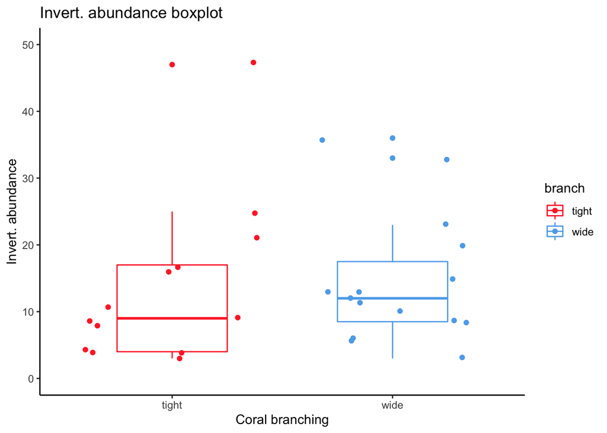

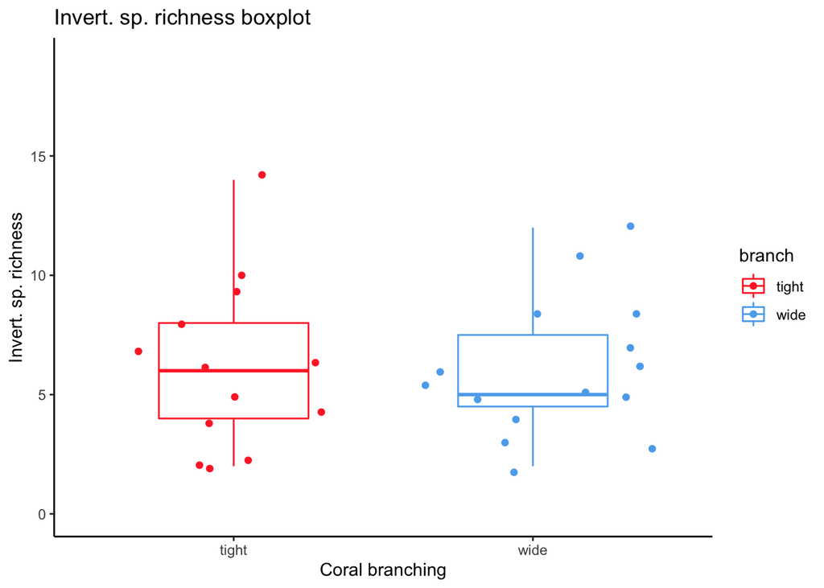

##### Qualitatively looking at boxplots would suggest invert abundance to be higher in wide branching corals and species richness to be higher in the tight branching corals.

### Visualize Trapezid data

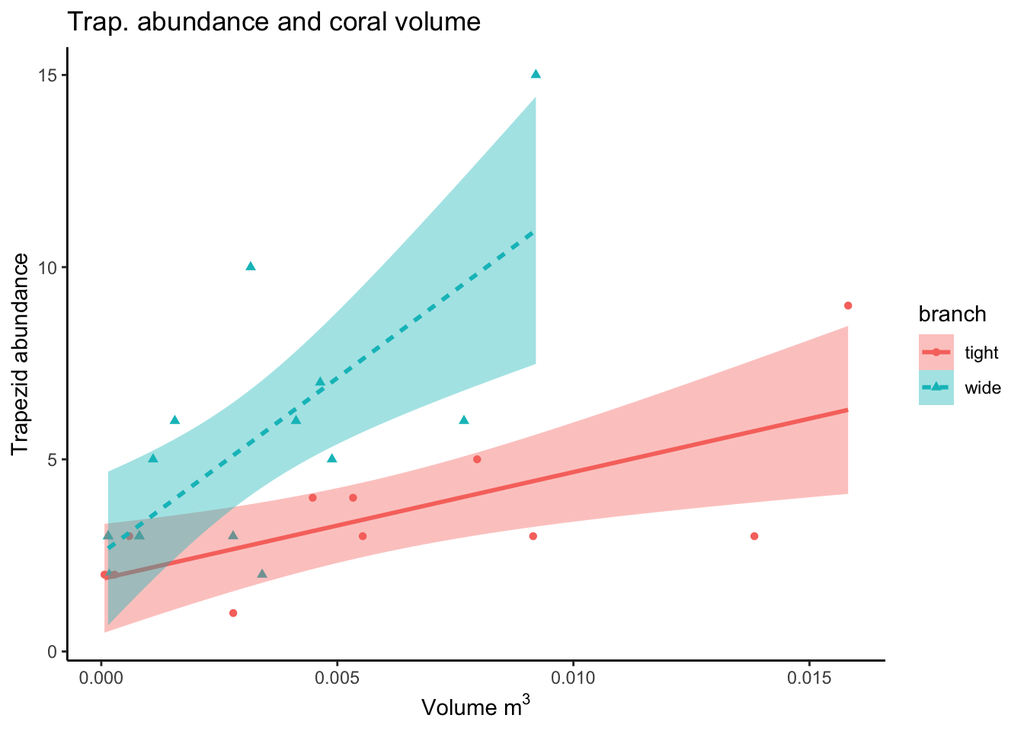

|  | Trap. abundance in tight coral |  |  | Trap abundance in wide coral |  |  |
| --- | --- | --- | --- | --- | --- | --- |
| Predictors | Estimates | CI | p | Estimates | CI | p |
| Intercept | 1.89 | 0.46 – 3.31 | **0.015** | 2.55 | 0.50 – 4.60 | **0.019** |
| Volume | 278.16 | 88.33 – 467.98 | **0.009** | 913.65 | 400.91 – 1426.40 | **0.002** |
| Observations | 12 |  |  | 15 |  |  |
| R<sup>2</sup> / R<sup>2</sup> adjusted | 0.516 / 0.468 |  |  | 0.533 / 0.497 |  |  |

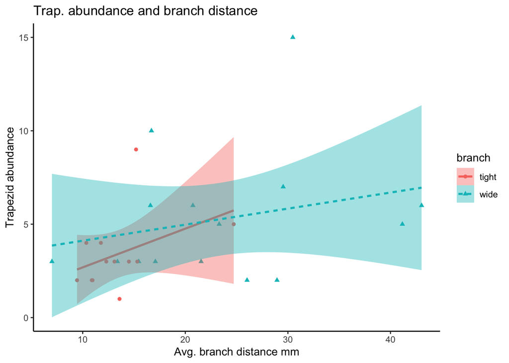

|  | Trap. abundance in tight coral |  |  | Trap abundance in wide coral |  |  |
| --- | --- | --- | --- | --- | --- | --- |
| Predictors | Estimates | CI | p | Estimates | CI | p |
| Intercept | 0.62 | -4.04 – 5.28 | 0.774 | 3.26 | -1.85 – 8.36 | 0.192 |
| Avg. branch distance | 0.21 | -0.12 – 0.54 | 0.194 | 0.09 | -0.12 – 0.29 | 0.374 |
| Observations | 12 |  |  | 15 |  |  |
| R<sup>2</sup> / R<sup>2</sup> adjusted | 0.162 / 0.078 |  |  | 0.061 / -0.011 |  |  |

##### Looking at the above analysis of avg. branch distance and trapezid abundance, none of the slopes are significantly different from zero and we cannot conlude that the slopes are signficantly different from eachother. Correlation between variables appears to be positive and greater in tight branching corals.

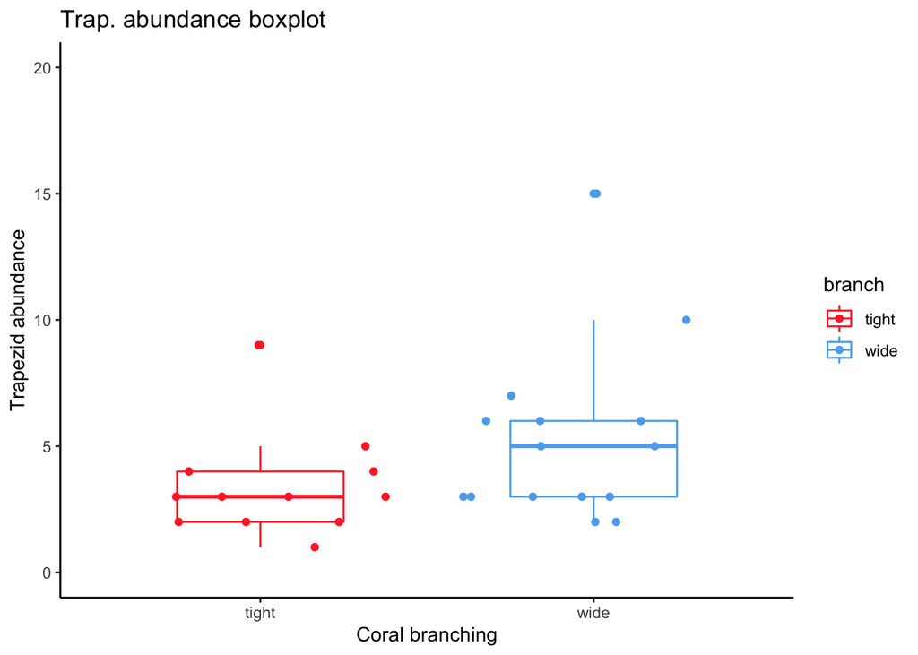

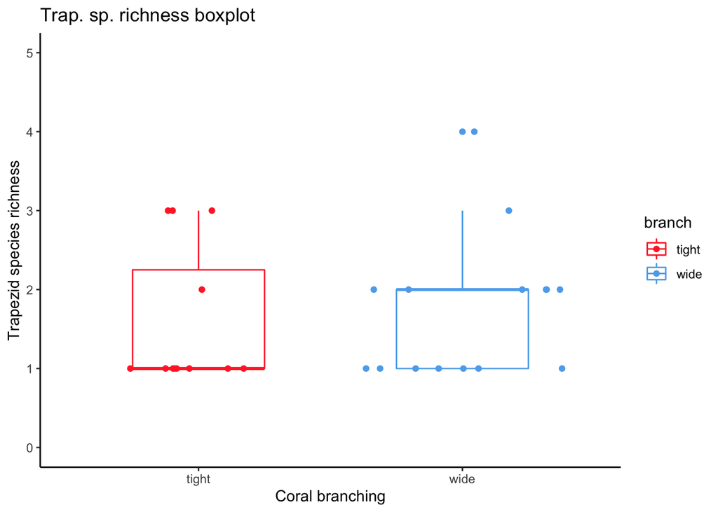

##### The above boxplot for trapezid abundance suggest trapezid abundance being higher in wide branching coral. There is not enough data to draw conclusions for species richness of trapezids.

### Visualize Alpheus shrimp data

##### There were not enough data points for Alepheus shrimp and we could not make predictions for shrimp abundance based on the high degree of scatter. Plots were included as a visual representation but will not be analyzed. We will wait for more species to be identified and further data cleaning.

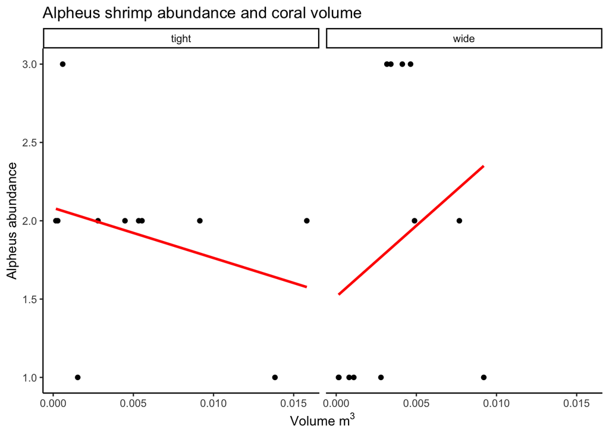

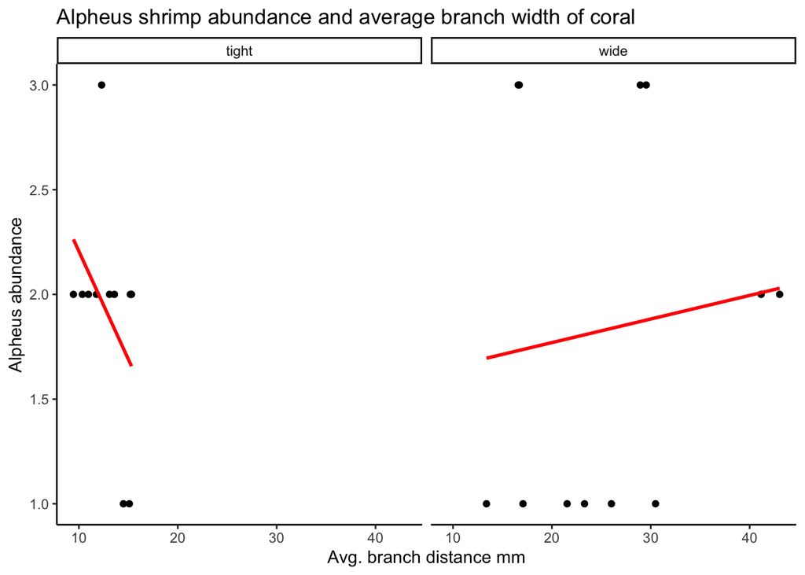

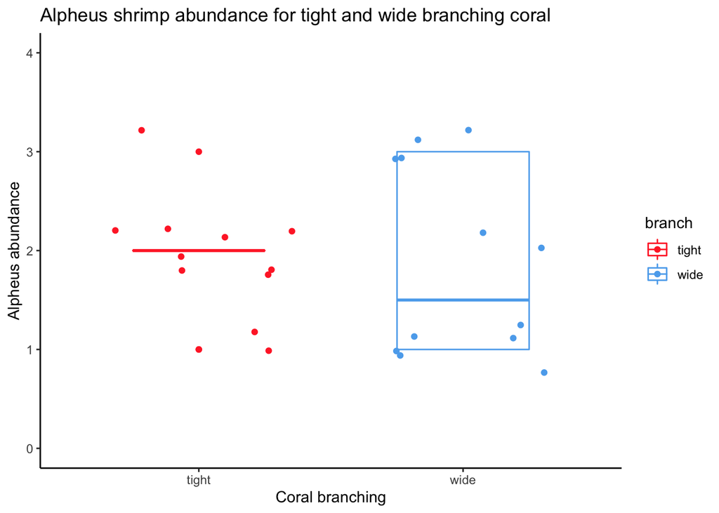

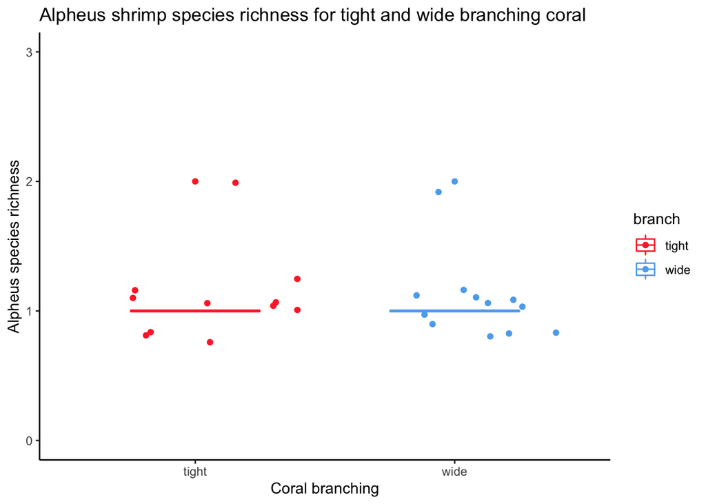